# Classfying the top 10 whale species

My goal here is to follow in the direction of the tutorial on this site (https://www.tensorflow.org/versions/r1.1/get_started/mnist/beginners). This tutorial shows us how to handwritten digits. My goal is to see if I can also apply this to classify whales.

## License (MIT)

Copyright (c) 2016 by [Magnus Erik Hvass Pedersen](http://www.hvass-labs.org/)

Permission is hereby granted, free of charge, to any person obtaining a copy of this software and associated documentation files (the "Software"), to deal in the Software without restriction, including without limitation the rights to use, copy, modify, merge, publish, distribute, sublicense, and/or sell copies of the Software, and to permit persons to whom the Software is furnished to do so, subject to the following conditions:

The above copyright notice and this permission notice shall be included in all copies or substantial portions of the Software.

THE SOFTWARE IS PROVIDED "AS IS", WITHOUT WARRANTY OF ANY KIND, EXPRESS OR IMPLIED, INCLUDING BUT NOT LIMITED TO THE WARRANTIES OF MERCHANTABILITY, FITNESS FOR A PARTICULAR PURPOSE AND NONINFRINGEMENT. IN NO EVENT SHALL THE AUTHORS OR COPYRIGHT HOLDERS BE LIABLE FOR ANY CLAIM, DAMAGES OR OTHER LIABILITY, WHETHER IN AN ACTION OF CONTRACT, TORT OR OTHERWISE, ARISING FROM, OUT OF OR IN CONNECTION WITH THE SOFTWARE OR THE USE OR OTHER DEALINGS IN THE SOFTWARE.

```python
%matplotlib inline
import matplotlib.pyplot as plt
import matplotlib.image as mpimg

def plot_images(images, cls_true, imgPath, cls_pred = None):
    assert len(images) == len(cls_true) == 9

    # Create 3x3 subplots.
    fig, axes = plt.subplots(3, 3)
    fig.subplots_adjust(hspace = 0.5, wspace = 0.5)

    for i, ax in enumerate(axes.flat):
        # Plot the image
        img = mpimg.imread(imgPath + images[i]) # I changed this to fit my needs. (Not from Pedersen)
        ax.imshow(img, cmap = 'binary') # I changed this to fit my needs. (Not from Pedersen)

        # Show the true and predicted classes.
        if cls_pred is None:
            xlabel = "True: {0}".format(cls_true[i])
        else:
            xlabel = "True: {0}, Pred: {1}".format(cls_true[i], cls_pred[i])

        # Show the classes as label on the x-axis.
        ax.set_xlabel(xlabel)

        #Remove ticks from the plot.
        ax.set_xticks([])
        ax.set_yticks([])

    plt.show()
```

## Function the creates a histogram out of the images.

Thanks for Jae Duk Seo for this code. He had a tutorial on YouTube explaining this and from the video he also links to his github.

- Youtube Video: https://www.youtube.com/watch?v=XCz46GQgWb0
- Github File: https://github.com/JaeDukSeo/Python_Basic_Image_Processing/blob/master/3_Image_Histogram/three.py

```python
from scipy import misc
from scipy import ndimage

def img_hist(img_path, img_label, img_path_2, img_path_2_label):
    image = mpimg.imread(img_path)
    hist, bin_edges = np.histogram(image, bins = 'auto')
    bin_centers = 0.5 * (bin_edges[: -1] + bin_edges[1:])

    plt.subplot(1, 2, 1)
    plt.title("Image One")
    plt.xlabel(img_label)
    plt.ylabel('Pixel Intensity')
    plt.plot(bin_centers, hist, lw = 2)

    imageTwo = mpimg.imread(img_path_2)
    hist, bin_edges = np.histogram(imageTwo, bins = 'auto')
    bin_centers = 0.5 * (bin_edges[: -1] + bin_edges[1:])

    plt.subplot(1, 2, 2)
    plt.title("Image Two")
    plt.xlabel(img_path_2_label)
    plt.ylabel('Pixel Intensity')
    plt.plot(bin_centers, hist, lw = 2)

    plt.tight_layout()

    plt.show()
```

```python
def get_hist(img_path):
    image = mpimg.imread(img_path)
    return np.histogram(image, bins = 'auto')
```

## Function to detect peaks.

Special thanks to Marcos Duarte for this code, taken from this link: http://nbviewer.jupyter.org/github/demotu/BMC/blob/master/notebooks/DetectPeaks.ipynb

```python
from __future__ import division, print_function
import numpy as np

__author__ = "Marcos Duarte, https://github.com/demotu/BMC"
__version__ = "1.0.4"
__license__ = "MIT"


def detect_peaks(x, mph=None, mpd=1, threshold=0, edge='rising',
                 kpsh=False, valley=False, show=False, ax=None):

    """Detect peaks in data based on their amplitude and other features.

    Parameters
    ----------
    x : 1D array_like
        data.
    mph : {None, number}, optional (default = None)
        detect peaks that are greater than minimum peak height.
    mpd : positive integer, optional (default = 1)
        detect peaks that are at least separated by minimum peak distance (in
        number of data).
    threshold : positive number, optional (default = 0)
        detect peaks (valleys) that are greater (smaller) than `threshold`
        in relation to their immediate neighbors.
    edge : {None, 'rising', 'falling', 'both'}, optional (default = 'rising')
        for a flat peak, keep only the rising edge ('rising'), only the
        falling edge ('falling'), both edges ('both'), or don't detect a
        flat peak (None).
    kpsh : bool, optional (default = False)
        keep peaks with same height even if they are closer than `mpd`.
    valley : bool, optional (default = False)
        if True (1), detect valleys (local minima) instead of peaks.
    show : bool, optional (default = False)
        if True (1), plot data in matplotlib figure.
    ax : a matplotlib.axes.Axes instance, optional (default = None).

    Returns
    -------
    ind : 1D array_like
        indeces of the peaks in `x`.

    Notes
    -----
    The detection of valleys instead of peaks is performed internally by simply
    negating the data: `ind_valleys = detect_peaks(-x)`

    The function can handle NaN's

    See this IPython Notebook [1]_.

    References
    ----------
    .. [1] http://nbviewer.ipython.org/github/demotu/BMC/blob/master/notebooks/DetectPeaks.ipynb

    Examples
    --------
    >>> from detect_peaks import detect_peaks
    >>> x = np.random.randn(100)
    >>> x[60:81] = np.nan
    >>> # detect all peaks and plot data
    >>> ind = detect_peaks(x, show=True)
    >>> print(ind)

    >>> x = np.sin(2*np.pi*5*np.linspace(0, 1, 200)) + np.random.randn(200)/5
    >>> # set minimum peak height = 0 and minimum peak distance = 20
    >>> detect_peaks(x, mph=0, mpd=20, show=True)

    >>> x = [0, 1, 0, 2, 0, 3, 0, 2, 0, 1, 0]
    >>> # set minimum peak distance = 2
    >>> detect_peaks(x, mpd=2, show=True)

    >>> x = np.sin(2*np.pi*5*np.linspace(0, 1, 200)) + np.random.randn(200)/5
    >>> # detection of valleys instead of peaks
    >>> detect_peaks(x, mph=0, mpd=20, valley=True, show=True)

    >>> x = [0, 1, 1, 0, 1, 1, 0]
    >>> # detect both edges
    >>> detect_peaks(x, edge='both', show=True)

    >>> x = [-2, 1, -2, 2, 1, 1, 3, 0]
    >>> # set threshold = 2
    >>> detect_peaks(x, threshold = 2, show=True)
    """

    x = np.atleast_1d(x).astype('float64')
    if x.size < 3:
        return np.array([], dtype=int)
    if valley:
        x = -x
    # find indices of all peaks
    dx = x[1:] - x[:-1]
    # handle NaN's
    indnan = np.where(np.isnan(x))[0]
    if indnan.size:
        x[indnan] = np.inf
        dx[np.where(np.isnan(dx))[0]] = np.inf
    ine, ire, ife = np.array([[], [], []], dtype=int)
    if not edge:
        ine = np.where((np.hstack((dx, 0)) < 0) & (np.hstack((0, dx)) > 0))[0]
    else:
        if edge.lower() in ['rising', 'both']:
            ire = np.where((np.hstack((dx, 0)) <= 0) & (np.hstack((0, dx)) > 0))[0]
        if edge.lower() in ['falling', 'both']:
            ife = np.where((np.hstack((dx, 0)) < 0) & (np.hstack((0, dx)) >= 0))[0]
    ind = np.unique(np.hstack((ine, ire, ife)))
    # handle NaN's
    if ind.size and indnan.size:
        # NaN's and values close to NaN's cannot be peaks
        ind = ind[np.in1d(ind, np.unique(np.hstack((indnan, indnan-1, indnan+1))), invert=True)]
    # first and last values of x cannot be peaks
    if ind.size and ind[0] == 0:
        ind = ind[1:]
    if ind.size and ind[-1] == x.size-1:
        ind = ind[:-1]
    # remove peaks < minimum peak height
    if ind.size and mph is not None:
        ind = ind[x[ind] >= mph]
    # remove peaks - neighbors < threshold
    if ind.size and threshold > 0:
        dx = np.min(np.vstack([x[ind]-x[ind-1], x[ind]-x[ind+1]]), axis=0)
        ind = np.delete(ind, np.where(dx < threshold)[0])
    # detect small peaks closer than minimum peak distance
    if ind.size and mpd > 1:
        ind = ind[np.argsort(x[ind])][::-1]  # sort ind by peak height
        idel = np.zeros(ind.size, dtype=bool)
        for i in range(ind.size):
            if not idel[i]:
                # keep peaks with the same height if kpsh is True
                idel = idel | (ind >= ind[i] - mpd) & (ind <= ind[i] + mpd) \
                    & (x[ind[i]] > x[ind] if kpsh else True)
                idel[i] = 0  # Keep current peak
        # remove the small peaks and sort back the indices by their occurrence
        ind = np.sort(ind[~idel])

    if show:
        if indnan.size:
            x[indnan] = np.nan
        if valley:
            x = -x
        _plot(x, mph, mpd, threshold, edge, valley, ax, ind)

    return ind


def _plot(x, mph, mpd, threshold, edge, valley, ax, ind):
    """Plot results of the detect_peaks function, see its help."""
    try:
        import matplotlib.pyplot as plt
    except ImportError:
        print('matplotlib is not available.')
    else:
        if ax is None:
            _, ax = plt.subplots(1, 1, figsize=(8, 4))

        ax.plot(x, 'b', lw=1)
        if ind.size:
            label = 'valley' if valley else 'peak'
            label = label + 's' if ind.size > 1 else label
            ax.plot(ind, x[ind], '+', mfc=None, mec='r', mew=2, ms=8,
                    label='%d %s' % (ind.size, label))
            ax.legend(loc='best', framealpha=.5, numpoints=1)
        ax.set_xlim(-.02*x.size, x.size*1.02-1)
        ymin, ymax = x[np.isfinite(x)].min(), x[np.isfinite(x)].max()
        yrange = ymax - ymin if ymax > ymin else 1
        ax.set_ylim(ymin - 0.1*yrange, ymax + 0.1*yrange)
        ax.set_xlabel('Data #', fontsize=14)
        ax.set_ylabel('Amplitude', fontsize=14)
        mode = 'Valley detection' if valley else 'Peak detection'
        ax.set_title("%s (mph=%s, mpd=%d, threshold=%s, edge='%s')"
                     % (mode, str(mph), mpd, str(threshold), edge))
        # plt.grid()

        plt.show()
```

## Function to plot a single image.

```python
def plot_image(img_path, img_label):
    image = mpimg.imread(img_path)
    plt.imshow(image)
```

## Code to read in file names and folder names.

This is meant to take the images once they have already been seperated into folders and the folders names have been changed to numbers.

```python
# Need this to match image names with their original ids.
import pandas as pd
import numpy as np

dataset = pd.read_csv('C:/Users/Keith Carlson Jr/Documents/CS 429 Whale Project/Untouched_Data/train.csv')

import os

# Set this to the path of the training images you want to get names of.
path_train_imgs = 'C:/Users/Keith Carlson Jr/Documents/CS 429 Whale Project/Attempt #5/train'

# Set this to the path of the test images you want to get names of.
path_test_imgs = 'C:/Users/Keith Carlson Jr/Documents/CS 429 Whale Project/Attempt #5/test'

train_img_names = []
train_img_labels = []

test_img_names = []
test_img_labels = []

for path, subdirs, files in os.walk(path_train_imgs):
    for filename in files:
        f = os.path.join(path, filename)
        imgName = f.split('\\')[2]
        train_img_names.append(imgName)

        img_label = dataset.loc[dataset["Image"] == imgName]['Id'].iloc[0]
        train_img_labels.append(img_label)

for path, subdirs, fils in os.walk(path_test_imgs):
    for filename in files:
        f = os.path.join(path, filename)
        if len(f.split('\\')) > 2:
            imgName = f.split('\\')[2]
            test_img_names.append(imgName)
            img_label = dataset.loc[dataset["Image"] == imgName]['Id'].iloc[0]
            test_img_labels.append(img_label)

# Covert the arrays to numpy arrays
train_img_names = np.asarray(train_img_names)
train_img_labels = np.asarray(train_img_labels)

test_img_names = np.asarray(test_img_names)
test_img_labels = np.asarray(test_img_labels)
```

## These are the original images from Kaggle

### Important! Set the path below to the path where the original untouched Kaggle training images are.

```python
kaggle_train_path = 'C:/Users/Keith Carlson Jr/Documents/CS 429 Whale Project/Untouched_Data/train/'
```

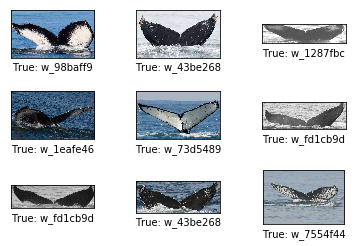

```python
# Plotting original images.

# Getting nine random image names.
images = train_img_names
np.random.shuffle(images)
images = images[0:9]

# Getting those random images corresponding ids.
image_ids = []

for image in images:
    image_ids.append(dataset.loc[dataset["Image"] == image]['Id'].iloc[0])

image_ids = np.asarray(image_ids)

# Plotting the images from the untouched Kaggle Data
plot_images(images, image_ids, kaggle_train_path)
```

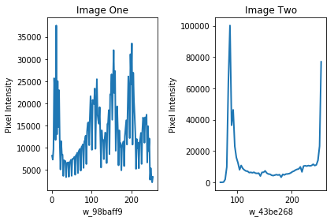

```python
# Starting from the top left and going right comparing the histograms of the
# first two images.

img_hist(kaggle_train_path + images[0],
         image_ids[0],
        kaggle_train_path + images[2],
        image_ids[1])
```

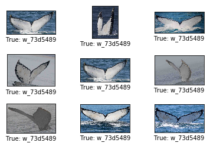

```python
# Plotting all the images in one folder (category)

# Just arbitrarily choose an image label.
img_label = train_img_labels[76]

# Get the image names with that label.
img_names = np.asarray(dataset.loc[dataset["Id"] == img_label]['Image'])[0:9]

# It is redundant I know but get the label of all these images and
# put them in a array of length 9 so they can be displayed.

img_ids = []

for image in img_names:
    img_ids.append(dataset.loc[dataset["Image"] == image]['Id'].iloc[0])

plot_images(img_names, img_ids, kaggle_train_path)
```

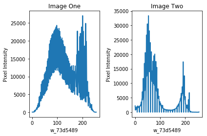

```python
# Now the hist of the top left and the one immediately to the right of it.
# Both are of the same class.

img_hist(kaggle_train_path + img_names[0],
        img_ids[0],
        kaggle_train_path + img_names[1],
        img_ids[1])
```

This seems to mean something. Trying to figure out how we can use this. Lets look at the number values of the histogram instead of the graph:

### Looking at Peaks of Image One

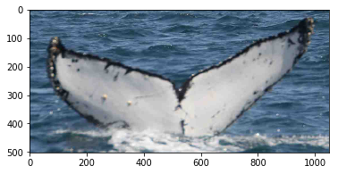

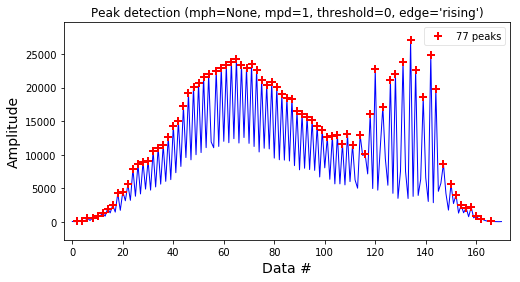

```
array([  2,   4,   6,   8,  10,  12,  14,  16,  18,  20,  22,  24,  26,
        28,  30,  32,  34,  36,  38,  40,  42,  44,  46,  48,  50,  52,
        54,  57,  59,  61,  63,  65,  67,  69,  71,  73,  75,  77,  79,
        81,  83,  85,  87,  89,  91,  93,  95,  97,  99, 101, 103, 105,
       107, 109, 111, 114, 116, 118, 120, 123, 126, 128, 131, 134, 136,
       139, 142, 144, 147, 150, 152, 154, 156, 158, 160, 162, 166], dtype=int64)
```

```python
# Path of that image.
img_path = kaggle_train_path + img_names[0]

# Array values of the histogram.
hist = get_hist(img_path) # Outputs a tuple

# Convert to numpy array.
hist = np.asarray(hist)

# Detecting peaks of Image One.
plot_image(img_path, img_ids[0])
detect_peaks(hist[0], show = True)
```

### Looking at Peaks of Image Two

Remeber that at this point Image One and Image Two are of the same category.

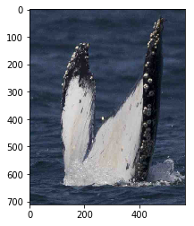

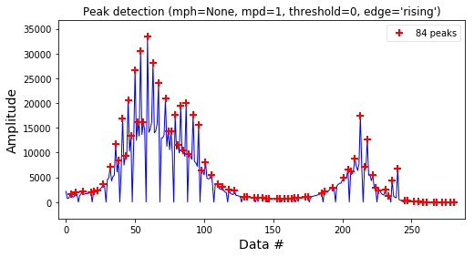

```
array([  4,   7,  12,  18,  20,  23,  27,  32,  36,  38,  41,  43,  45,
        47,  50,  52,  54,  56,  59,  63,  67,  72,  74,  76,  79,  81,
        83,  85,  87,  89,  92,  96,  98, 101, 105, 110, 113, 118, 122,
       129, 131, 136, 139, 142, 145, 147, 153, 155, 158, 161, 163, 165,
       168, 173, 175, 185, 187, 193, 201, 204, 206, 209, 213, 216, 218,
       222, 224, 226, 231, 233, 236, 240, 245, 247, 252, 255, 258, 261,
       266, 268, 272, 275, 278, 281], dtype=int64)
```

```python
# Path of that image.
img_path = kaggle_train_path + img_names[1]

# Array values of the histogram.
hist = get_hist(img_path)

# Convert to numpt array.
hist = np.asarray(hist)

# Detecting peaks of Image Two.
plot_image(img_path, img_ids[1])
detect_peaks(hist[0], show = True)
```

Interesting that these have very similar number of peaks and same general shape. That is easy for us to see but getting a computer to recognize could be tough.

I want to look at the peaks of one more image of this class.

### Looking at peaks of a third image of that class.

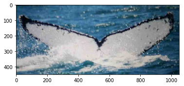

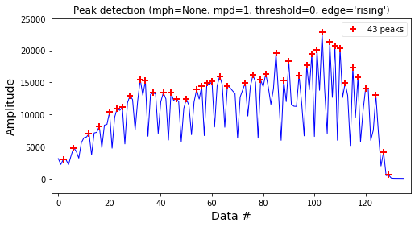

```
array([  2,   6,  12,  16,  20,  23,  25,  28,  32,  34,  37,  41,  44,
        46,  50,  54,  56,  58,  60,  63,  66,  73,  76,  79,  81,  85,
        88,  90,  94,  97,  99, 101, 103, 106, 108, 110, 112, 115, 117,
       120, 124, 127, 129], dtype=int64)
```

```python
# Path of that image.
img_path = kaggle_train_path + img_names[2]

# Array values of the histogram.
hist = get_hist(img_path)

# Convert to numpy array.
hist = np.asarray(hist)

# Detecting peaks of this third image.
plot_image(img_path, img_ids[2])
detect_peaks(hist[0], show = True)
```

Oh no this one looks like it has significantly different looking peaks. Maybe this is not a good way to look at things.

My next idea is to convert all the images to a same size and convert them to black and white. It'll be interesting to see exactly what this does.

This is also a good idea because we can get closer to getting our images in the form of the MNIST data set. More on this later.

## Original Images Converted to black and white.

```python
# Set this to the path of the black and white images.

b_w_images = 'C:/Users/Keith Carlson Jr/Documents/CS 429 Whale Project/Untouched_Data/b_w/train/'
```

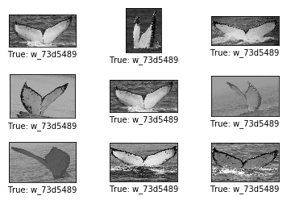

```python
# Displaying images of the same class.

plot_images(img_names, img_ids, b_w_images)
```

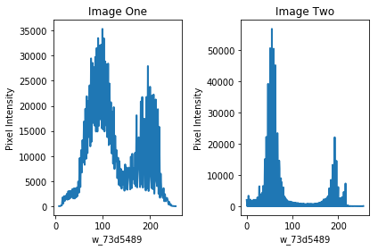

```python
# Looking about how their histograms change.

img_hist (b_w_images + img_names[0],
         img_ids[0],
         b_w_images + img_names[1],
         img_ids[1])
```

The histograms look almost identical! Changing to black and white did not change much atleast in terms of Pixel Density.

Now looking at peaks.

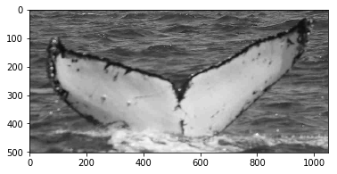

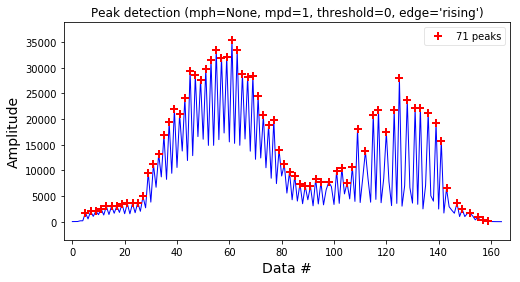

```
array([  5,   7,   9,  11,  13,  15,  17,  19,  21,  23,  25,  27,  29,
        31,  33,  35,  37,  39,  41,  43,  45,  47,  49,  51,  53,  55,
        57,  59,  61,  63,  65,  67,  69,  71,  73,  75,  77,  79,  81,
        83,  85,  87,  89,  91,  93,  95,  98, 101, 103, 105, 107, 109,
       112, 115, 117, 120, 123, 125, 128, 131, 133, 136, 139, 141, 143,
       147, 149, 152, 155, 157, 159], dtype=int64)
```

```python
# Path of Image One.
img_path = b_w_images + img_names[0]

# Array values of the historgram.
hist = get_hist(img_path)

# Convert to numpy as array.
hist = np.asarray(hist)

# Detecting peaks of this image.
plot_image(img_path, img_ids[0])
detect_peaks(hist[0], show = True)
```

We found a lot of good tutorials on training tensorlfow to classify digits in the MNIST data set. Those seemed like a good options. The tutorials all classify ten digits and we can take top ten most occuring whale species and see if we can get it to work with a MNIST tutorial.

The MNIST images and their labels are stored in a special format so here is what we converted them to before running a script to convert them into MNIST format. The format is scaling them all to size (28, 28) and making them black and white.

## This is what the images look like in MNIST form.

```python
# Location of scaled down (28 x 28) black and white images.

scaled_b_w_images = 'C:/Users/Keith Carlson Jr/Documents/CS 429 Whale Project/Attempt #5/resized_images/'
```

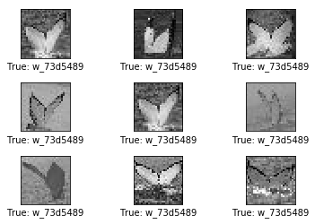

```python
# Plotting the images that have been scaled down and made black and white.

plot_images(img_names, img_ids, scaled_b_w_images)
```

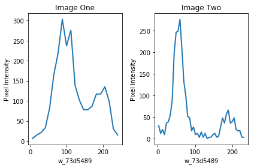

```python
# Histograms for these smaller images.

img_hist (scaled_b_w_images + img_names[0],
         img_ids[0],
         scaled_b_w_images + img_names[1],
         img_ids[1])
```

Still have the same general shape!

Looking at peaks.

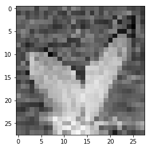

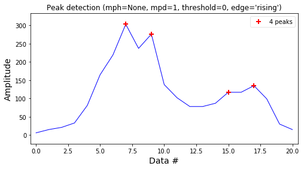

```
array([ 7,  9, 15, 17], dtype=int64)
```

```python
# Path of Image One.
img_path = scaled_b_w_images + img_names[0]

# Array values of the histogram.
hist = get_hist(img_path)

# Convert to numpy as array.
hist = np.asarray(hist)

# Detecting peaks of Image One.
plot_image(img_path, img_ids[0])
detect_peaks(hist[0], show = True)
```

## Moving on to trying to plug this into the "Hello World" Tensorflow tutorial.

This tutorial comes from the Tensorflow website, most of the code is copied from there. Here is the link: https://www.tensorflow.org/versions/r1.1/get_started/mnist/beginners

Thanks to gskielian (github) for providing code to easily convert the images into a MNIST format. I ran his code on the images once they were scaled to 28 x 28 and made black and white. His code outputted zipped ubyte files. Below is me loading in those files.

https://github.com/gskielian/JPG-PNG-to-MNIST-NN-Format

The code for below comes with help from here: https://stackoverflow.com/questions/48257255/how-to-import-pre-downloaded-mnist-dataset-from-a-specific-directory-or-folder

```python
from tensorflow.contrib.learn.python.learn.datasets.mnist import extract_images, extract_labels

with open('C:/Users/Keith Carlson Jr/Documents/CS 429 Whale Project/Attempt #5/data/train-images-idx3-ubyte.gz', 'rb') as f:
    train_images = extract_images(f)

with open('C:/Users/Keith Carlson Jr/Documents/CS 429 Whale Project/Attempt #5/data/train-labels-idx1-ubyte.gz', 'rb') as f:
    train_labels = extract_labels(f)

with open('C:/Users/Keith Carlson Jr/Documents/CS 429 Whale Project/Attempt #5/data/test-images-idx3-ubyte.gz', 'rb') as f:
    test_images = extract_images(f)

with open('C:/Users/Keith Carlson Jr/Documents/CS 429 Whale Project/Attempt #5/data/test-labels-idx1-ubyte.gz', 'rb') as f:
    test_labels = extract_labels(f)
```

```
Extracting C:/Users/Keith Carlson Jr/Documents/CS 429 Whale Project/Attempt #5/data/train-images-idx3-ubyte.gz
Extracting C:/Users/Keith Carlson Jr/Documents/CS 429 Whale Project/Attempt #5/data/train-labels-idx1-ubyte.gz
Extracting C:/Users/Keith Carlson Jr/Documents/CS 429 Whale Project/Attempt #5/data/test-images-idx3-ubyte.gz
Extracting C:/Users/Keith Carlson Jr/Documents/CS 429 Whale Project/Attempt #5/data/test-labels-idx1-ubyte.gz
```

The dimensions of the array seem to be off compared with the usual MNIST data. Going to just force the array into the right shape for now.

https://stackoverflow.com/questions/41203137/how-do-you-reduce-the-dimension-of-a-numpy-array

```python
train_images = train_images[:, :, 1].reshape(172, 28)
test_images = test_images[:, :, 1].reshape(45, 28)
```

The MNIST labels are encoded in whats called "one-hot encoding". So here is some code that one-hot encodes my labels.

https://stackoverflow.com/questions/33681517/tensorflow-one-hot-encoder

```python
# One-hot encoding the training labels

import tensorflow as tf

arr = []
for i in range(172):
    arr.append(i)

train_labels = tf.one_hot(indices=arr, depth = 10)

with tf.Session() as sess:
    sess.run(train_labels)

train_labels = train_labels.eval()

print(type(train_labels))
```

```
<class 'numpy.ndarray'>
```

```python
# One-hot encoding the test labels

arr = []
for i in range(45):
    arr.append(i)

test_labels = tf.one_hot(indices=arr, depth = 10)

with tf.Session() as sess:
    sess.run(test_labels)

test_labels = test_labels.eval()

print(type(test_labels))
```

```
<class 'numpy.ndarray'>
```

```python
# Checking to make sure the shapes match up.

train_images.shape
```

```
(172, 28)
```

```python
test_images.shape
```

```
(45, 28)
```

```python
import tensorflow as tf
```

```python
pixels = 28 * 28
```

```python
x = tf.placeholder(tf.float32, [None, 28])
W = tf.Variable(tf.zeros([28, 10]))
b = tf.Variable(tf.zeros([10]))
```

```python
y = tf.nn.softmax(tf.matmul(x, W) + b)
```

```python
y_ = tf.placeholder(tf.float32, [None, 10])
```

```python
cross_entropy = tf.reduce_mean(-tf.reduce_sum(y_ * tf.log(y), reduction_indices = [1]))
```

```python
train_step = tf.train.GradientDescentOptimizer(0.5).minimize(cross_entropy)
```

```python
sess = tf.InteractiveSession()
```

```python
tf.global_variables_initializer().run()
```

In the tutorial they use a function to get batchs of data. I needed to write my own to match the whale data. That is what this function is. Thanks to this source for help:

https://stackoverflow.com/questions/40994583/how-to-implement-tensorflows-next-batch-for-own-data

```python
import numpy as np

def next_batch(num, data, labels):
    idx = np.arange(0, len(data))
    np.random.shuffle(idx)
    idx = idx[:num]
    data_shuffle = [data[i] for i in idx]
    labels_shuffle = [labels[i] for i in idx]
    return np.asarray(data_shuffle), np.asarray(labels_shuffle)
```

```python
for _ in range(12):
    batch_xs, batch_ys = next_batch(2, train_images, train_labels)
    #print(train_labels.shape)
    #print(batch_xs.shape)
    #print(batch_ys.shape)
    #break
    sess.run(train_step, feed_dict = {x: batch_xs, y_ : batch_ys})
```

```python
correct_prediction = tf.equal(tf.argmax(y, 1), tf.argmax(y_, 1))
```

```python
accuracy = tf.reduce_mean(tf.cast(correct_prediction, tf.float32))
```

This prints the accuracy of the model. 80% does not seem bad at all! I am suspicious of this though because as seen below it classifies everything as having zeros. Something is wrong and I unfortunately do not know enough to be able to fix it.

```python
print((sess.run(accuracy, feed_dict = {x: test_images, y_: test_labels})) * 100)
```

```
80.0000011920929
```

```python
print(sess.run(tf.argmax(y, 1), feed_dict = {x:train_images}))
```

```
[0 0 0 0 0 0 0 0 0 0 0 0 0 0 0 0 0 0 0 0 0 0 0 0 0 0 0 0 0 0 0 0 0 0 0 0 0
 0 0 0 0 0 0 0 0 0 0 0 0 0 0 0 0 0 0 0 0 0 0 0 0 0 0 0 0 0 0 0 0 0 0 0 0 0
 0 0 0 0 0 0 0 0 0 0 0 0 0 0 0 0 0 0 0 0 0 0 0 0 0 0 0 0 0 0 0 0 0 0 0 0 0
 0 0 0 0 0 0 0 0 0 0 0 0 0 0 0 0 0 0 0 0 0 0 0 0 0 0 0 0 0 0 0 0 0 0 0 0 0
 0 0 0 0 0 0 0 0 0 0 0 0 0 0 0 0 0 0 0 0 0 0 0 0]
```

## Helpful Sources

- Converting Tensor to numpy array https://www.aiworkbox.com/lessons/numpy-array-to-tensorflow-tensor-and-back
- Reading in image names - https://stackoverflow.com/questions/12199120/python-list-all-the-file-names-in-a-directory-and-its-subdirectories-and-then-p
- Plotting help - https://matplotlib.org/gallery/pyplots/pyplot_text.html#sphx-glr-gallery-pyplots-pyplot-text-py
  - https://stackoverflow.com/questions/42818361/how-to-make-two-plots-side-by-side-using-python
- Searching through pandas dataframe help - https://stackoverflow.com/questions/17071871/select-rows-from-a-dataframe-based-on-values-in-a-column-in-pandas